# Assignment 2: Explore Gapminder and use dplyr

# Exercise 1: Basic `dplyr`

## 1.1

*Use `filter()` to subset the gapminder data to three countries of your choice in the 1970’s.*

ANSWER:

```r
filtered <- gapminder %>%
  filter(year>=1970 & year<1980) %>%
  filter(country=='Norway' | country=='Sweden' | country=='Denmark')
kable(filtered)
```

| country | continent | year | lifeExp | pop | gdpPercap |
| --- | --- | --- | --- | --- | --- |
| Denmark | Europe | 1972 | 73.47 | 4991596 | 18866.21 |
| Denmark | Europe | 1977 | 74.69 | 5088419 | 20422.90 |
| Norway | Europe | 1972 | 74.34 | 3933004 | 18965.06 |
| Norway | Europe | 1977 | 75.37 | 4043205 | 23311.35 |
| Sweden | Europe | 1972 | 74.72 | 8122293 | 17832.02 |
| Sweden | Europe | 1977 | 75.44 | 8251648 | 18855.73 |

## 1.2

*Use the pipe operator `%>%` to select “country” and “gdpPercap” from your filtered dataset in 1.1.*

ANSWER:

```r
filtered %>%
  select(country, gdpPercap) %>%
  kable()
```

| country | gdpPercap |
| --- | --- |
| Denmark | 18866.21 |
| Denmark | 20422.90 |
| Norway | 18965.06 |
| Norway | 23311.35 |
| Sweden | 17832.02 |
| Sweden | 18855.73 |

## 1.3

*Filter gapminder to all entries that have experienced a drop in life expectancy. Be sure to include a new variable that’s the increase in life expectancy in your tibble. Hint: you might find the `lag()` or `diff()` functions useful.*

ANSWER:

```r
gapminder %>%
  group_by(country) %>%
  arrange(year) %>%
  mutate(change=round(lifeExp-lag(lifeExp, 1), 3)) %>% #round to 3 decimal places
  filter(change<0) %>%
  datatable(as_tibble())
```

|  | country | continent | year | lifeExp | pop | gdpPercap | change |
| --- | --- | --- | --- | --- | --- | --- | --- |
| 1 | China | Asia | 1962 | 44.50136 | 665770000 | 487.6740183 | -6.048 |
| 2 | Cambodia | Asia | 1972 | 40.317 | 7450606 | 421.6240257 | -5.098 |
| 3 | Czech Republic | Europe | 1972 | 70.29 | 9862158 | 13108.4536 | -0.09 |
| 4 | Netherlands | Europe | 1972 | 73.75 | 13329874 | 18794.74567 | -0.07 |
| 5 | Slovak Republic | Europe | 1972 | 70.35 | 4593433 | 9674.167626 | -0.63 |
| 6 | Bulgaria | Europe | 1977 | 70.81 | 8797022 | 7612.240438 | -0.09 |
| 7 | Cambodia | Asia | 1977 | 31.22 | 6978607 | 524.9721832 | -9.097 |
| 8 | El Salvador | Americas | 1977 | 56.696 | 4282586 | 5138.922374 | -1.511 |
| 9 | Poland | Europe | 1977 | 70.67 | 34621254 | 9508.141454 | -0.18 |
| 10 | Uganda | Africa | 1977 | 50.35 | 11457758 | 843.7331372 | -0.666 |

[output cut: 92 more lines]

## 1.4

Exercise chosen:

*Filter gapminder so that it shows the max GDP per capita experienced by each country. Hint: you might find the `max()` function useful here.*

ANSWER:

```r
gapminder %>%
  group_by(country) %>%
  filter(gdpPercap==max(gdpPercap)) %>%
  datatable(as_tibble())
```

|  | country | continent | year | lifeExp | pop | gdpPercap |
| --- | --- | --- | --- | --- | --- | --- |
| 1 | Afghanistan | Asia | 1982 | 39.854 | 12881816 | 978.0114388 |
| 2 | Albania | Europe | 2007 | 76.423 | 3600523 | 5937.029526 |
| 3 | Algeria | Africa | 2007 | 72.301 | 33333216 | 6223.367465 |
| 4 | Angola | Africa | 1967 | 35.985 | 5247469 | 5522.776375 |
| 5 | Argentina | Americas | 2007 | 75.32 | 40301927 | 12779.37964 |
| 6 | Australia | Oceania | 2007 | 81.235 | 20434176 | 34435.36744 |
| 7 | Austria | Europe | 2007 | 79.829 | 8199783 | 36126.4927 |
| 8 | Bahrain | Asia | 2007 | 75.635 | 708573 | 29796.04834 |
| 9 | Bangladesh | Asia | 2007 | 64.062 | 150448339 | 1391.253792 |
| 10 | Belgium | Europe | 2007 | 79.441 | 10392226 | 33692.60508 |

[output cut: 132 more lines]

## 1.5

*Produce a scatterplot of Canada’s life expectancy vs. GDP per capita using ggplot2, without defining a new variable. That is, after filtering the gapminder data set, pipe it directly into the `ggplot()` function. Ensure GDP per capita is on a log scale.*

ANSWER:

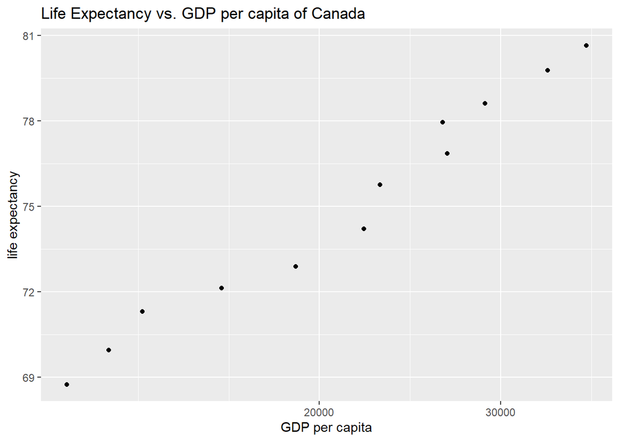

```r
gapminder %>%
  filter(country=='Canada') %>%
  ggplot(aes(x=gdpPercap, y=lifeExp)) + geom_point() + scale_x_log10() + ggtitle("Life Expectancy vs. GDP per capita of Canada") + xlab("GDP per capita") + ylab("life expectancy")
```

# Exercise 2: Explore individual variables with `dplyr`

*Pick one categorical variable and one quantitative variable to explore. Answer the following questions in whichever way you think is appropriate, using `dplyr`:*

Variables chosen:

- `continent` (qualitative)
- `pop` (quantitative)

*What are possible values (or range, whichever is appropriate) of each variable?*

ANSWER:

Possible values for continent:

| continent |
| --- |
| Asia |
| Europe |
| Africa |
| Americas |
| Oceania |

Minimum and maximum values (range) of pop, respectively:

| x |
| --- |
| 60011 |
| 1318683096 |

*What values are typical? What’s the spread? What’s the distribution? Etc., tailored to the variable at hand. Feel free to use summary stats, tables, figures.*

ANSWER:

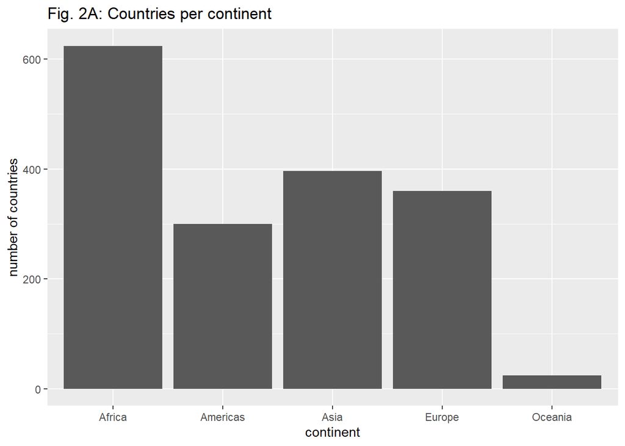

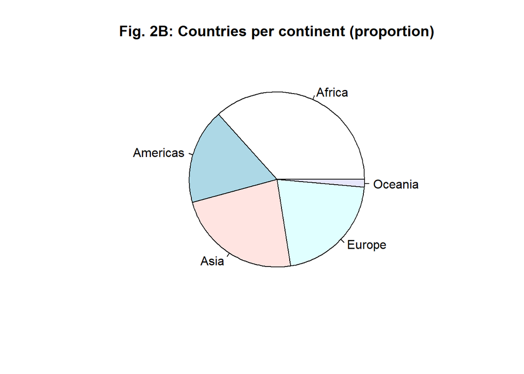

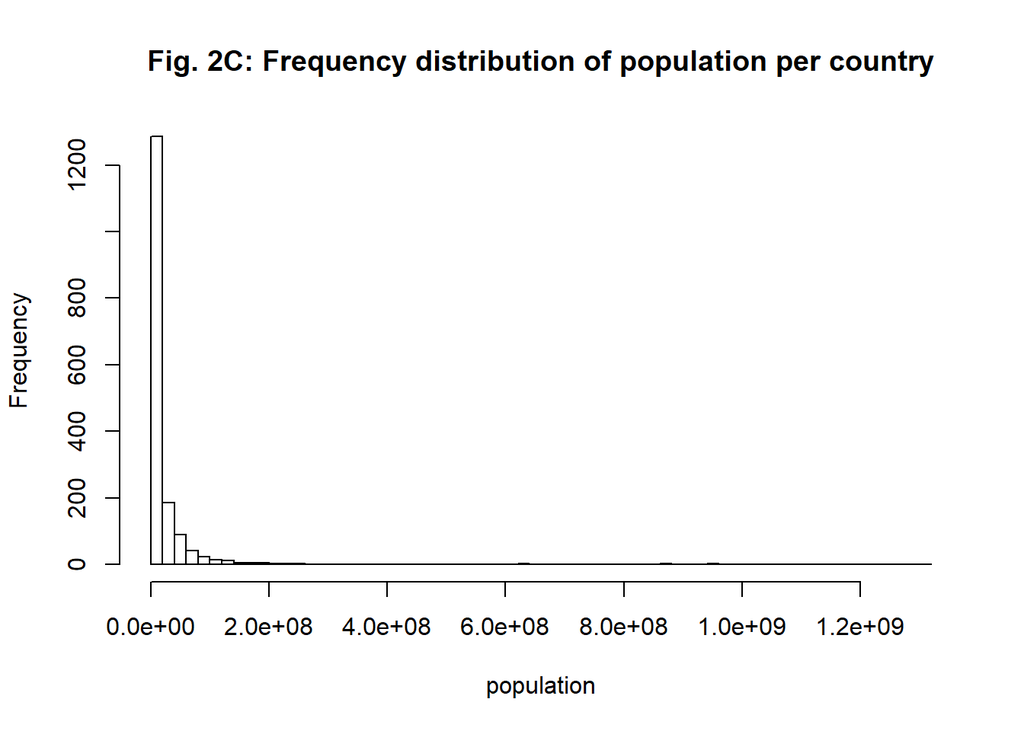

# Exercise 3: Explore various plot types

*Make two plots that have some value to them. That is, plots that someone might actually consider making for an analysis. Just don’t make the same plots we made in class – feel free to use a data set from the datasets R package if you wish.*

- *A scatterplot of two quantitative variables.*
- *One other plot besides a scatterplot.*

*You don’t have to use all the data in every plot! It’s fine to filter down to one country or a small handful of countries.*

ANSWER:

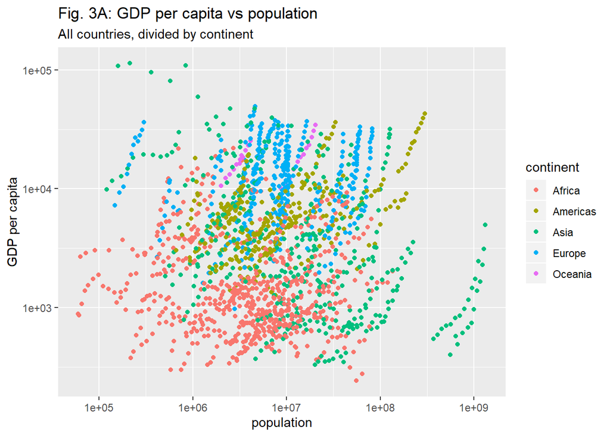

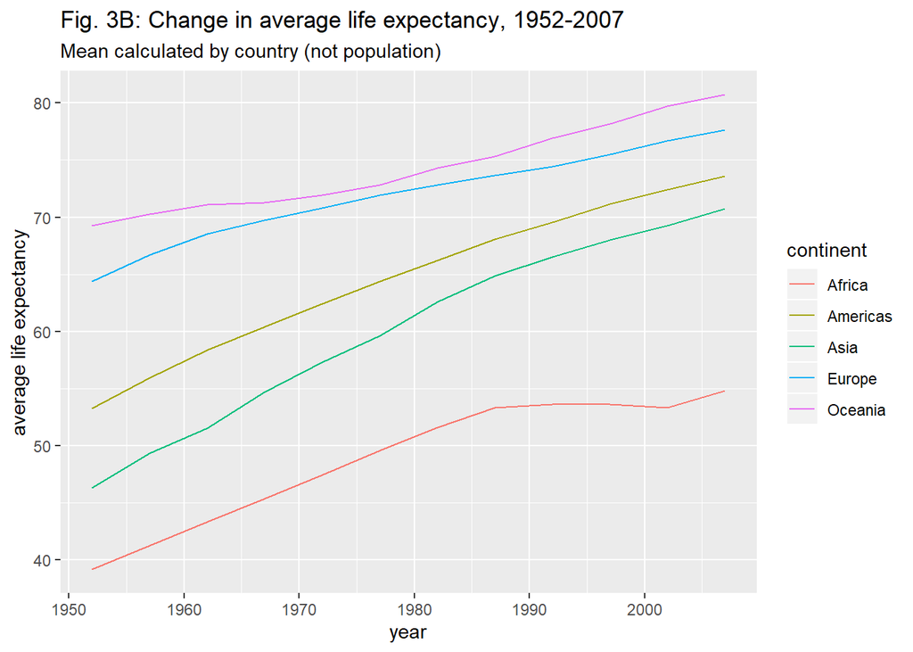

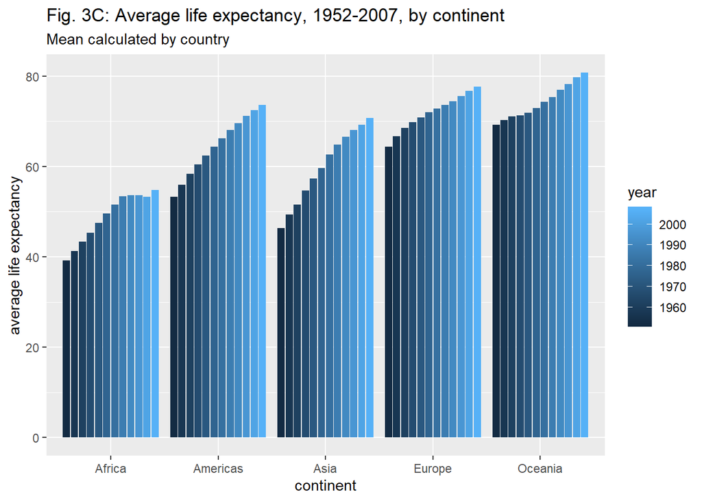

## Discussion

- **Fig. 3A:** GDP per capita vs population for each country, with colour differentiating countries of each continent. From this scatter plot, we can see that Asia has the greatest variability in GDP per capita vs population, with data points on both the upper left and lower right of the graph. Both the x and y axes have been adjusted to a logarithmic scale.
- **Fig. 3B:** change in life expectancy for each continent over time. Overall, all the continents have experienced an increase in life expectancy, with different patterns of change (e.g. Africa’s increase plateaued in the 1990s).
  - Though this graph manipulates data a little differently than what was made in class, it’s still a line plot, so another visualization of this same data was attempted…
- **Fig. 3C:** Grouped bar graph of average life expectancy by continent. Here, the years are split into separate ‘sub-bars’ within each continent. It conveys much of the same information as Fig. 3B. Note that for both Fic. 3B and 3C, the average life expectancy was weighted by country and not population, i.e. a country of 300 people and a country of 300,000 people are equally ‘important’ in the mean calculation.
  - **Revision:** Not long after writing up this discussion, it was (shamefully) realized that grouped bar graphs of this type might more typically present data like the following…

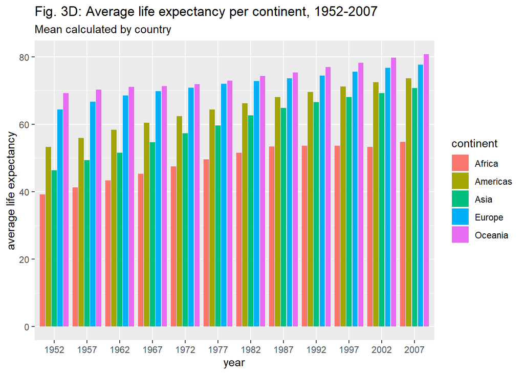

  - But the emphasis of this presentation shifts instead to the difference between continents, and not changes within each continent over the years. Plus, with 12 years (and thus 12 bars) to keep track of, the data sure becomes crowded and hard to follow.

# Recycling

Evaluate this code and describe the result. Presumably the analyst’s intent was to get the data for Rwanda and Afghanistan. Did they succeed? Why or why not? If not, what is the correct way to do this?

```r
filter(gapminder, country == c("Rwanda", "Afghanistan")) %>%
  kable()
```

| country | continent | year | lifeExp | pop | gdpPercap |
| --- | --- | --- | --- | --- | --- |
| Afghanistan | Asia | 1957 | 30.332 | 9240934 | 820.8530 |
| Afghanistan | Asia | 1967 | 34.020 | 11537966 | 836.1971 |
| Afghanistan | Asia | 1977 | 38.438 | 14880372 | 786.1134 |
| Afghanistan | Asia | 1987 | 40.822 | 13867957 | 852.3959 |
| Afghanistan | Asia | 1997 | 41.763 | 22227415 | 635.3414 |
| Afghanistan | Asia | 2007 | 43.828 | 31889923 | 974.5803 |
| Rwanda | Africa | 1952 | 40.000 | 2534927 | 493.3239 |
| Rwanda | Africa | 1962 | 43.000 | 3051242 | 597.4731 |
| Rwanda | Africa | 1972 | 44.600 | 3992121 | 590.5807 |
| Rwanda | Africa | 1982 | 46.218 | 5507565 | 881.5706 |
| Rwanda | Africa | 1992 | 23.599 | 7290203 | 737.0686 |
| Rwanda | Africa | 2002 | 43.413 | 7852401 | 785.6538 |

The analyst was not successful. They only managed to pull half of the data that is required from the dataset. This is because of the vector input in the `filter()` function.

Somehow dplyr is aware of how many results should be returned if the `filter()` was run with only one country name. So before the software even gets to what the “country” entry should be, it has already divvied up the dataframe in anticipation of searching by country. When it then processes the vector, it ‘checks off’ each entry it finds in its pre-divided groups, except with each entry the country name it’s looking for gets switched out from under its nose (so to speak).

The function returns a set of results that contains a full suite of years (1952-2007), as for one country, but the country that dplyr is filtering for changes between “Rwanda” and “Afghanistan” because a vector of multiple objects is used instead of a single object.

The end result is a dataset that has one complete suite of years (1952-2007) but where the country alternates between “Rwanda” and “Afghanistan”. Thus only half of what the analyst was looking for was recovered. If a third country was added, the query would cycle between all of them:

```r
filter(gapminder, country == c("Rwanda", "Afghanistan", "Argentina")) %>%
  kable()
```

| country | continent | year | lifeExp | pop | gdpPercap |
| --- | --- | --- | --- | --- | --- |
| Afghanistan | Asia | 1957 | 30.332 | 9240934 | 820.8530 |
| Afghanistan | Asia | 1972 | 36.088 | 13079460 | 739.9811 |
| Afghanistan | Asia | 1987 | 40.822 | 13867957 | 852.3959 |
| Afghanistan | Asia | 2002 | 42.129 | 25268405 | 726.7341 |
| Argentina | Americas | 1962 | 65.142 | 21283783 | 7133.1660 |
| Argentina | Americas | 1977 | 68.481 | 26983828 | 10079.0267 |
| Argentina | Americas | 1992 | 71.868 | 33958947 | 9308.4187 |
| Argentina | Americas | 2007 | 75.320 | 40301927 | 12779.3796 |
| Rwanda | Africa | 1952 | 40.000 | 2534927 | 493.3239 |
| Rwanda | Africa | 1967 | 44.100 | 3451079 | 510.9637 |
| Rwanda | Africa | 1982 | 46.218 | 5507565 | 881.5706 |
| Rwanda | Africa | 1997 | 36.087 | 7212583 | 589.9445 |

The correct way to code this query would be (ignoring the second line which is to format the resulting table):

```r
filter(gapminder, country=="Rwanda" | country=="Afghanistan") %>%
  datatable(as_tibble())
```

|  | country | continent | year | lifeExp | pop | gdpPercap |
| --- | --- | --- | --- | --- | --- | --- |
| 1 | Afghanistan | Asia | 1952 | 28.801 | 8425333 | 779.4453145 |
| 2 | Afghanistan | Asia | 1957 | 30.332 | 9240934 | 820.8530296 |
| 3 | Afghanistan | Asia | 1962 | 31.997 | 10267083 | 853.10071 |
| 4 | Afghanistan | Asia | 1967 | 34.02 | 11537966 | 836.1971382 |
| 5 | Afghanistan | Asia | 1972 | 36.088 | 13079460 | 739.9811058 |
| 6 | Afghanistan | Asia | 1977 | 38.438 | 14880372 | 786.11336 |
| 7 | Afghanistan | Asia | 1982 | 39.854 | 12881816 | 978.0114388 |
| 8 | Afghanistan | Asia | 1987 | 40.822 | 13867957 | 852.3959448 |
| 9 | Afghanistan | Asia | 1992 | 41.674 | 16317921 | 649.3413952 |
| 10 | Afghanistan | Asia | 1997 | 41.763 | 22227415 | 635.341351 |

[output cut: 14 more lines]